# Risk Factor Analysis

## Outcome Variable

**Outcome Variable:** haz

## Predictor Variables

**Intervention Variable:** feducyrs

**Adjustment Set:**

unadjusted

## Stratifying Variables

The analysis was stratified on these variable(s):

- agecat
- studyid
- country

## Data Summary

| agecat | studyid | country | feducyrs | n_cell | n |
| --- | --- | --- | --- | --- | --- |
| Birth | ki0047075b-MAL-ED | BANGLADESH | High | 52 | 144 |
| Birth | ki0047075b-MAL-ED | BANGLADESH | Low | 38 | 144 |
| Birth | ki0047075b-MAL-ED | BANGLADESH | Medium | 54 | 144 |
| Birth | ki0047075b-MAL-ED | INDIA | High | 38 | 123 |
| Birth | ki0047075b-MAL-ED | INDIA | Low | 50 | 123 |
| Birth | ki0047075b-MAL-ED | INDIA | Medium | 35 | 123 |
| Birth | ki0047075b-MAL-ED | NEPAL | High | 27 | 67 |
| Birth | ki0047075b-MAL-ED | NEPAL | Low | 19 | 67 |
| Birth | ki0047075b-MAL-ED | NEPAL | Medium | 21 | 67 |
| Birth | ki0047075b-MAL-ED | PERU | High | 116 | 236 |
| Birth | ki0047075b-MAL-ED | PERU | Low | 65 | 236 |
| Birth | ki0047075b-MAL-ED | PERU | Medium | 55 | 236 |
| Birth | ki0047075b-MAL-ED | SOUTH AFRICA | High | 35 | 91 |
| Birth | ki0047075b-MAL-ED | SOUTH AFRICA | Low | 30 | 91 |
| Birth | ki0047075b-MAL-ED | SOUTH AFRICA | Medium | 26 | 91 |
| Birth | ki0047075b-MAL-ED | TANZANIA, UNITED REPUBLIC OF | High | 65 | 101 |
| Birth | ki0047075b-MAL-ED | TANZANIA, UNITED REPUBLIC OF | Low | 29 | 101 |
| Birth | ki0047075b-MAL-ED | TANZANIA, UNITED REPUBLIC OF | Medium | 7 | 101 |
| Birth | ki1000304b-SAS-CompFeed | INDIA | High | 34 | 187 |
| Birth | ki1000304b-SAS-CompFeed | INDIA | Low | 79 | 187 |
| Birth | ki1000304b-SAS-CompFeed | INDIA | Medium | 74 | 187 |
| Birth | ki1017093c-NIH-Crypto | BANGLADESH | High | 8 | 27 |
| Birth | ki1017093c-NIH-Crypto | BANGLADESH | Low | 12 | 27 |
| Birth | ki1017093c-NIH-Crypto | BANGLADESH | Medium | 7 | 27 |
| Birth | ki1119695-PROBIT | BELARUS | High | 2058 | 13416 |
| Birth | ki1119695-PROBIT | BELARUS | Low | 5316 | 13416 |
| Birth | ki1119695-PROBIT | BELARUS | Medium | 6042 | 13416 |
| Birth | ki1126311-ZVITAMBO | ZIMBABWE | High | 976 | 13460 |
| Birth | ki1126311-ZVITAMBO | ZIMBABWE | Low | 2276 | 13460 |
| Birth | ki1126311-ZVITAMBO | ZIMBABWE | Medium | 10208 | 13460 |

[output cut: 129 more lines]

The following strata were considered:

- agecat: 24 months, studyid: ki0047075b-MAL-ED, country: BANGLADESH
- agecat: 24 months, studyid: ki0047075b-MAL-ED, country: INDIA
- agecat: 24 months, studyid: ki0047075b-MAL-ED, country: NEPAL
- agecat: 24 months, studyid: ki0047075b-MAL-ED, country: PERU
- agecat: 24 months, studyid: ki0047075b-MAL-ED, country: SOUTH AFRICA
- agecat: 24 months, studyid: ki0047075b-MAL-ED, country: TANZANIA, UNITED REPUBLIC OF
- agecat: 24 months, studyid: ki1017093b-PROVIDE, country: BANGLADESH
- agecat: 24 months, studyid: ki1017093c-NIH-Crypto, country: BANGLADESH
- agecat: 24 months, studyid: ki1066203-TanzaniaChild2, country: TANZANIA, UNITED REPUBLIC OF
- agecat: 24 months, studyid: ki1113344-GMS-Nepal, country: NEPAL
- agecat: 24 months, studyid: ki1119695-PROBIT, country: BELARUS
- agecat: 24 months, studyid: ki1126311-ZVITAMBO, country: ZIMBABWE
- agecat: 24 months, studyid: ki1135781-COHORTS, country: GUATEMALA
- agecat: 24 months, studyid: ki1135781-COHORTS, country: INDIA
- agecat: 24 months, studyid: ki1135781-COHORTS, country: PHILIPPINES
- agecat: 24 months, studyid: ki1148112-LCNI-5, country: MALAWI
- agecat: 24 months, studyid: kiGH5241-JiVitA-3, country: BANGLADESH
- agecat: 24 months, studyid: kiGH5241-JiVitA-4, country: BANGLADESH
- agecat: 6 months, studyid: ki0047075b-MAL-ED, country: BANGLADESH
- agecat: 6 months, studyid: ki0047075b-MAL-ED, country: INDIA
- agecat: 6 months, studyid: ki0047075b-MAL-ED, country: NEPAL
- agecat: 6 months, studyid: ki0047075b-MAL-ED, country: PERU
- agecat: 6 months, studyid: ki0047075b-MAL-ED, country: SOUTH AFRICA
- agecat: 6 months, studyid: ki0047075b-MAL-ED, country: TANZANIA, UNITED REPUBLIC OF
- agecat: 6 months, studyid: ki1000304b-SAS-CompFeed, country: INDIA
- agecat: 6 months, studyid: ki1000304b-SAS-FoodSuppl, country: INDIA
- agecat: 6 months, studyid: ki1017093b-PROVIDE, country: BANGLADESH
- agecat: 6 months, studyid: ki1017093c-NIH-Crypto, country: BANGLADESH
- agecat: 6 months, studyid: ki1066203-TanzaniaChild2, country: TANZANIA, UNITED REPUBLIC OF
- agecat: 6 months, studyid: ki1113344-GMS-Nepal, country: NEPAL
- agecat: 6 months, studyid: ki1119695-PROBIT, country: BELARUS
- agecat: 6 months, studyid: ki1126311-ZVITAMBO, country: ZIMBABWE
- agecat: 6 months, studyid: ki1135781-COHORTS, country: GUATEMALA
- agecat: 6 months, studyid: ki1135781-COHORTS, country: INDIA
- agecat: 6 months, studyid: ki1135781-COHORTS, country: PHILIPPINES
- agecat: 6 months, studyid: ki1148112-LCNI-5, country: MALAWI
- agecat: 6 months, studyid: kiGH5241-JiVitA-3, country: BANGLADESH
- agecat: 6 months, studyid: kiGH5241-JiVitA-4, country: BANGLADESH
- agecat: Birth, studyid: ki0047075b-MAL-ED, country: BANGLADESH
- agecat: Birth, studyid: ki0047075b-MAL-ED, country: INDIA
- agecat: Birth, studyid: ki0047075b-MAL-ED, country: NEPAL
- agecat: Birth, studyid: ki0047075b-MAL-ED, country: PERU
- agecat: Birth, studyid: ki0047075b-MAL-ED, country: SOUTH AFRICA
- agecat: Birth, studyid: ki0047075b-MAL-ED, country: TANZANIA, UNITED REPUBLIC OF
- agecat: Birth, studyid: ki1000304b-SAS-CompFeed, country: INDIA
- agecat: Birth, studyid: ki1017093c-NIH-Crypto, country: BANGLADESH
- agecat: Birth, studyid: ki1119695-PROBIT, country: BELARUS
- agecat: Birth, studyid: ki1126311-ZVITAMBO, country: ZIMBABWE
- agecat: Birth, studyid: ki1135781-COHORTS, country: GUATEMALA
- agecat: Birth, studyid: ki1135781-COHORTS, country: INDIA
- agecat: Birth, studyid: ki1135781-COHORTS, country: PHILIPPINES
- agecat: Birth, studyid: kiGH5241-JiVitA-3, country: BANGLADESH
- agecat: Birth, studyid: kiGH5241-JiVitA-4, country: BANGLADESH

### Dropped Strata

Some strata were dropped due to rare outcomes:

- agecat: 24 months, studyid: ki1066203-TanzaniaChild2, country: TANZANIA, UNITED REPUBLIC OF

## Methods Detail

We’re interested in the causal parameters $E[Y_a]$ for all values of $a \in \mathcal{A}$. These parameters represent the mean outcome if, possibly contrary to fact, we intervened to set all units to have $A=a$. Under the randomization and positivity assumptions, these are identified by the statistical parameters $\psi_a=E_W[E_{Y|A,W}(Y|A=a,W)]$. In addition, we’re interested in the mean of $Y$, $E[Y]$ under no intervention (the observed mean). We will estimate these parameters by using SuperLearner to fit the relevant likelihood factors – $E_{Y|A,W}(Y|A=a,W)$ and $p(A=a|W)$, and then updating our likelihood fit using a joint TMLE.

For unadjusted analyses ($W=\{\}$), initial likelihoods were estimated using Lrnr_glm to estimate the simple $E(Y|A)$ and Lrnr_mean to estimate $p(A)$. For adjusted analyses, a small library containing Lrnr_glmnet, Lrnr_xgboost, and Lrnr_mean was used.

# Results Detail

## Results Plots

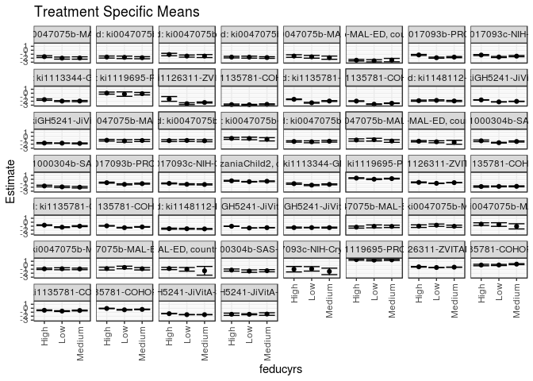

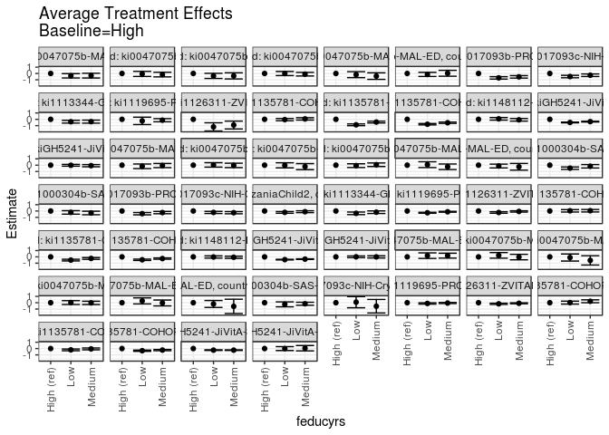

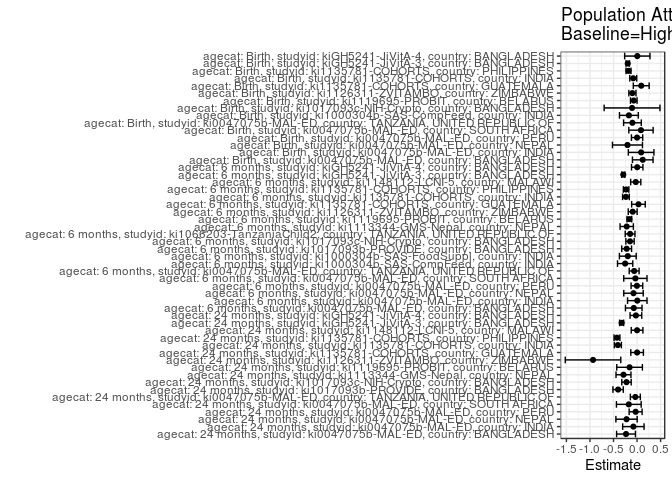

## Results Table

### Parameter: TSM

| agecat | studyid | country | intervention_level | baseline_level | estimate | ci_lower | ci_upper |
| --- | --- | --- | --- | --- | --- | --- | --- |
| Birth | ki0047075b-MAL-ED | BANGLADESH | High | NA | -1.2300000 | -1.4838603 | -0.9761397 |
| Birth | ki0047075b-MAL-ED | BANGLADESH | Low | NA | -1.0389474 | -1.3970784 | -0.6808164 |
| Birth | ki0047075b-MAL-ED | BANGLADESH | Medium | NA | -1.0420370 | -1.3390022 | -0.7450719 |
| Birth | ki0047075b-MAL-ED | INDIA | High | NA | -0.9807895 | -1.3137126 | -0.6478663 |
| Birth | ki0047075b-MAL-ED | INDIA | Low | NA | -0.7452000 | -1.0398693 | -0.4505307 |
| Birth | ki0047075b-MAL-ED | INDIA | Medium | NA | -1.0128571 | -1.2886675 | -0.7370468 |
| Birth | ki0047075b-MAL-ED | NEPAL | High | NA | -0.4788889 | -0.8145510 | -0.1432268 |
| Birth | ki0047075b-MAL-ED | NEPAL | Low | NA | -0.5826316 | -1.0294361 | -0.1358270 |
| Birth | ki0047075b-MAL-ED | NEPAL | Medium | NA | -1.0342857 | -1.6877780 | -0.3807935 |
| Birth | ki0047075b-MAL-ED | PERU | High | NA | -0.9062931 | -1.0768668 | -0.7357194 |
| Birth | ki0047075b-MAL-ED | PERU | Low | NA | -0.8835385 | -1.1343662 | -0.6327108 |
| Birth | ki0047075b-MAL-ED | PERU | Medium | NA | -0.9309091 | -1.1257413 | -0.7360769 |
| Birth | ki0047075b-MAL-ED | SOUTH AFRICA | High | NA | -0.8471429 | -1.2004791 | -0.4938066 |
| Birth | ki0047075b-MAL-ED | SOUTH AFRICA | Low | NA | -0.5620000 | -0.8823507 | -0.2416493 |
| Birth | ki0047075b-MAL-ED | SOUTH AFRICA | Medium | NA | -0.8850000 | -1.1842018 | -0.5857982 |
| Birth | ki0047075b-MAL-ED | TANZANIA, UNITED REPUBLIC OF | High | NA | -0.8247692 | -1.1152019 | -0.5343366 |
| Birth | ki0047075b-MAL-ED | TANZANIA, UNITED REPUBLIC OF | Low | NA | -1.0258621 | -1.4907115 | -0.5610127 |
| Birth | ki0047075b-MAL-ED | TANZANIA, UNITED REPUBLIC OF | Medium | NA | -1.4028571 | -2.4977820 | -0.3079322 |
| Birth | ki1000304b-SAS-CompFeed | INDIA | High | NA | -1.2214706 | -1.4935953 | -0.9493458 |
| Birth | ki1000304b-SAS-CompFeed | INDIA | Low | NA | -1.4784810 | -1.7827919 | -1.1741701 |
| Birth | ki1000304b-SAS-CompFeed | INDIA | Medium | NA | -1.3847297 | -1.6578394 | -1.1116201 |
| Birth | ki1017093c-NIH-Crypto | BANGLADESH | High | NA | -1.0037500 | -1.6907705 | -0.3167295 |
| Birth | ki1017093c-NIH-Crypto | BANGLADESH | Low | NA | -0.9183333 | -1.4761431 | -0.3605236 |
| Birth | ki1017093c-NIH-Crypto | BANGLADESH | Medium | NA | -1.5600000 | -2.3817661 | -0.7382339 |
| Birth | ki1119695-PROBIT | BELARUS | High | NA | 1.4041399 | 1.2358387 | 1.5724412 |
| Birth | ki1119695-PROBIT | BELARUS | Low | NA | 1.2876279 | 1.1059335 | 1.4693223 |
| Birth | ki1119695-PROBIT | BELARUS | Medium | NA | 1.3517925 | 1.1959385 | 1.5076464 |
| Birth | ki1126311-ZVITAMBO | ZIMBABWE | High | NA | -0.3994877 | -0.4780099 | -0.3209655 |
| Birth | ki1126311-ZVITAMBO | ZIMBABWE | Low | NA | -0.5761555 | -0.6274212 | -0.5248898 |
| Birth | ki1126311-ZVITAMBO | ZIMBABWE | Medium | NA | -0.4903870 | -0.5142118 | -0.4665621 |

[output cut: 126 more lines]

### Parameter: E(Y)

| agecat | studyid | country | intervention_level | baseline_level | estimate | ci_lower | ci_upper |
| --- | --- | --- | --- | --- | --- | --- | --- |
| Birth | ki0047075b-MAL-ED | BANGLADESH | NA | NA | -1.1090972 | -1.2821831 | -0.9360114 |
| Birth | ki0047075b-MAL-ED | INDIA | NA | NA | -0.8941463 | -1.0718260 | -0.7164667 |
| Birth | ki0047075b-MAL-ED | NEPAL | NA | NA | -0.6823881 | -0.9646995 | -0.4000766 |
| Birth | ki0047075b-MAL-ED | PERU | NA | NA | -0.9057627 | -1.0235263 | -0.7879991 |
| Birth | ki0047075b-MAL-ED | SOUTH AFRICA | NA | NA | -0.7639560 | -0.9583680 | -0.5695441 |
| Birth | ki0047075b-MAL-ED | TANZANIA, UNITED REPUBLIC OF | NA | NA | -0.9225743 | -1.1664549 | -0.6786936 |
| Birth | ki1000304b-SAS-CompFeed | INDIA | NA | NA | -1.3946524 | -1.5833612 | -1.2059436 |
| Birth | ki1017093c-NIH-Crypto | BANGLADESH | NA | NA | -1.1100000 | -1.5086894 | -0.7113106 |
| Birth | ki1119695-PROBIT | BELARUS | NA | NA | 1.3343977 | 1.1746915 | 1.4941040 |
| Birth | ki1126311-ZVITAMBO | ZIMBABWE | NA | NA | -0.4982987 | -0.5191445 | -0.4774528 |
| Birth | ki1135781-COHORTS | GUATEMALA | NA | NA | 0.1369030 | 0.0500914 | 0.2237146 |
| Birth | ki1135781-COHORTS | INDIA | NA | NA | -0.6011965 | -0.6594222 | -0.5429708 |
| Birth | ki1135781-COHORTS | PHILIPPINES | NA | NA | -0.2407379 | -0.2807613 | -0.2007145 |
| Birth | kiGH5241-JiVitA-3 | BANGLADESH | NA | NA | -1.5685983 | -1.5887531 | -1.5484435 |
| Birth | kiGH5241-JiVitA-4 | BANGLADESH | NA | NA | -1.5193126 | -1.6248757 | -1.4137496 |
| 6 months | ki0047075b-MAL-ED | BANGLADESH | NA | NA | -1.0801894 | -1.2248166 | -0.9355622 |
| 6 months | ki0047075b-MAL-ED | INDIA | NA | NA | -1.0957005 | -1.2405754 | -0.9508256 |
| 6 months | ki0047075b-MAL-ED | NEPAL | NA | NA | -0.6134211 | -0.7965750 | -0.4302671 |
| 6 months | ki0047075b-MAL-ED | PERU | NA | NA | -1.3230208 | -1.4411177 | -1.2049240 |
| 6 months | ki0047075b-MAL-ED | SOUTH AFRICA | NA | NA | -0.9833877 | -1.1756113 | -0.7911640 |
| 6 months | ki0047075b-MAL-ED | TANZANIA, UNITED REPUBLIC OF | NA | NA | -1.3177032 | -1.4548809 | -1.1805254 |
| 6 months | ki1000304b-SAS-CompFeed | INDIA | NA | NA | -1.4006377 | -1.4802862 | -1.3209891 |
| 6 months | ki1000304b-SAS-FoodSuppl | INDIA | NA | NA | -1.8986842 | -2.0118892 | -1.7854792 |
| 6 months | ki1017093b-PROVIDE | BANGLADESH | NA | NA | -1.0871041 | -1.1635539 | -1.0106543 |
| 6 months | ki1017093c-NIH-Crypto | BANGLADESH | NA | NA | -1.1986783 | -1.2700937 | -1.1272630 |
| 6 months | ki1066203-TanzaniaChild2 | TANZANIA, UNITED REPUBLIC OF | NA | NA | -0.5442042 | -0.5932639 | -0.4951446 |
| 6 months | ki1113344-GMS-Nepal | NEPAL | NA | NA | -1.3338820 | -1.4121646 | -1.2555993 |
| 6 months | ki1119695-PROBIT | BELARUS | NA | NA | 0.1181349 | 0.0244298 | 0.2118400 |
| 6 months | ki1126311-ZVITAMBO | ZIMBABWE | NA | NA | -0.8840215 | -0.9103442 | -0.8576988 |
| 6 months | ki1135781-COHORTS | GUATEMALA | NA | NA | -1.8074115 | -1.8776669 | -1.7371562 |
| 6 months | ki1135781-COHORTS | INDIA | NA | NA | -0.9755018 | -1.0332483 | -0.9177553 |
| 6 months | ki1135781-COHORTS | PHILIPPINES | NA | NA | -1.1419345 | -1.1847445 | -1.0991244 |
| 6 months | ki1148112-LCNI-5 | MALAWI | NA | NA | -1.6442734 | -1.7137349 | -1.5748119 |
| 6 months | kiGH5241-JiVitA-3 | BANGLADESH | NA | NA | -1.3073109 | -1.3309979 | -1.2836240 |
| 6 months | kiGH5241-JiVitA-4 | BANGLADESH | NA | NA | -1.3498252 | -1.3977574 | -1.3018930 |
| 24 months | ki0047075b-MAL-ED | BANGLADESH | NA | NA | -1.8419658 | -1.9985654 | -1.6853663 |
| 24 months | ki0047075b-MAL-ED | INDIA | NA | NA | -1.7871970 | -1.9519446 | -1.6224494 |
| 24 months | ki0047075b-MAL-ED | NEPAL | NA | NA | -1.3050000 | -1.4938380 | -1.1161620 |
| 24 months | ki0047075b-MAL-ED | PERU | NA | NA | -1.7560976 | -1.8841319 | -1.6280632 |
| 24 months | ki0047075b-MAL-ED | SOUTH AFRICA | NA | NA | -1.6331868 | -1.8397539 | -1.4266197 |
| 24 months | ki0047075b-MAL-ED | TANZANIA, UNITED REPUBLIC OF | NA | NA | -2.5456780 | -2.6911200 | -2.4002359 |
| 24 months | ki1017093b-PROVIDE | BANGLADESH | NA | NA | -1.5861179 | -1.6693668 | -1.5028689 |
| 24 months | ki1017093c-NIH-Crypto | BANGLADESH | NA | NA | -1.4295331 | -1.5127726 | -1.3462935 |
| 24 months | ki1113344-GMS-Nepal | NEPAL | NA | NA | -1.8850636 | -1.9697435 | -1.8003837 |
| 24 months | ki1119695-PROBIT | BELARUS | NA | NA | -0.1248692 | -0.4220079 | 0.1722694 |
| 24 months | ki1126311-ZVITAMBO | ZIMBABWE | NA | NA | -2.3650922 | -2.4839447 | -2.2462396 |
| 24 months | ki1135781-COHORTS | GUATEMALA | NA | NA | -2.8522915 | -2.9193797 | -2.7852032 |
| 24 months | ki1135781-COHORTS | INDIA | NA | NA | -1.9321014 | -1.9930806 | -1.8711223 |
| 24 months | ki1135781-COHORTS | PHILIPPINES | NA | NA | -2.4020743 | -2.4479290 | -2.3562197 |
| 24 months | ki1148112-LCNI-5 | MALAWI | NA | NA | -1.8678984 | -1.9495904 | -1.7862065 |
| 24 months | kiGH5241-JiVitA-3 | BANGLADESH | NA | NA | -2.0060871 | -2.0338879 | -1.9782862 |
| 24 months | kiGH5241-JiVitA-4 | BANGLADESH | NA | NA | -1.7501299 | -1.7959342 | -1.7043256 |

### Parameter: ATE

| agecat | studyid | country | intervention_level | baseline_level | estimate | ci_lower | ci_upper |
| --- | --- | --- | --- | --- | --- | --- | --- |
| Birth | ki0047075b-MAL-ED | BANGLADESH | High | High | 0.0000000 | 0.0000000 | 0.0000000 |
| Birth | ki0047075b-MAL-ED | BANGLADESH | Low | High | 0.1910526 | -0.2479267 | 0.6300320 |
| Birth | ki0047075b-MAL-ED | BANGLADESH | Medium | High | 0.1879630 | -0.2027202 | 0.5786461 |
| Birth | ki0047075b-MAL-ED | INDIA | High | High | 0.0000000 | 0.0000000 | 0.0000000 |
| Birth | ki0047075b-MAL-ED | INDIA | Low | High | 0.2355895 | -0.2090090 | 0.6801879 |
| Birth | ki0047075b-MAL-ED | INDIA | Medium | High | -0.0320677 | -0.4643976 | 0.4002622 |
| Birth | ki0047075b-MAL-ED | NEPAL | High | High | 0.0000000 | 0.0000000 | 0.0000000 |
| Birth | ki0047075b-MAL-ED | NEPAL | Low | High | -0.1037427 | -0.6625838 | 0.4550984 |
| Birth | ki0047075b-MAL-ED | NEPAL | Medium | High | -0.5553968 | -1.2900540 | 0.1792603 |
| Birth | ki0047075b-MAL-ED | PERU | High | High | 0.0000000 | 0.0000000 | 0.0000000 |
| Birth | ki0047075b-MAL-ED | PERU | Low | High | 0.0227546 | -0.2805767 | 0.3260860 |
| Birth | ki0047075b-MAL-ED | PERU | Medium | High | -0.0246160 | -0.2835658 | 0.2343338 |
| Birth | ki0047075b-MAL-ED | SOUTH AFRICA | High | High | 0.0000000 | 0.0000000 | 0.0000000 |
| Birth | ki0047075b-MAL-ED | SOUTH AFRICA | Low | High | 0.2851429 | -0.1917964 | 0.7620821 |
| Birth | ki0047075b-MAL-ED | SOUTH AFRICA | Medium | High | -0.0378571 | -0.5008563 | 0.4251420 |
| Birth | ki0047075b-MAL-ED | TANZANIA, UNITED REPUBLIC OF | High | High | 0.0000000 | 0.0000000 | 0.0000000 |
| Birth | ki0047075b-MAL-ED | TANZANIA, UNITED REPUBLIC OF | Low | High | -0.2010928 | -0.7492134 | 0.3470277 |
| Birth | ki0047075b-MAL-ED | TANZANIA, UNITED REPUBLIC OF | Medium | High | -0.5780879 | -1.7108772 | 0.5547014 |
| Birth | ki1000304b-SAS-CompFeed | INDIA | High | High | 0.0000000 | 0.0000000 | 0.0000000 |
| Birth | ki1000304b-SAS-CompFeed | INDIA | Low | High | -0.2570104 | -0.6489379 | 0.1349171 |
| Birth | ki1000304b-SAS-CompFeed | INDIA | Medium | High | -0.1632591 | -0.3991139 | 0.0725956 |
| Birth | ki1017093c-NIH-Crypto | BANGLADESH | High | High | 0.0000000 | 0.0000000 | 0.0000000 |
| Birth | ki1017093c-NIH-Crypto | BANGLADESH | Low | High | 0.0854167 | -0.7995404 | 0.9703737 |
| Birth | ki1017093c-NIH-Crypto | BANGLADESH | Medium | High | -0.5562500 | -1.6273694 | 0.5148694 |
| Birth | ki1119695-PROBIT | BELARUS | High | High | 0.0000000 | 0.0000000 | 0.0000000 |
| Birth | ki1119695-PROBIT | BELARUS | Low | High | -0.1165120 | -0.2200044 | -0.0130197 |
| Birth | ki1119695-PROBIT | BELARUS | Medium | High | -0.0523475 | -0.1371295 | 0.0324346 |
| Birth | ki1126311-ZVITAMBO | ZIMBABWE | High | High | 0.0000000 | 0.0000000 | 0.0000000 |
| Birth | ki1126311-ZVITAMBO | ZIMBABWE | Low | High | -0.1766678 | -0.2704437 | -0.0828920 |
| Birth | ki1126311-ZVITAMBO | ZIMBABWE | Medium | High | -0.0908992 | -0.1729563 | -0.0088422 |

[output cut: 126 more lines]

### Parameter: PAR

| agecat | studyid | country | intervention_level | baseline_level | estimate | ci_lower | ci_upper |
| --- | --- | --- | --- | --- | --- | --- | --- |
| Birth | ki0047075b-MAL-ED | BANGLADESH | High | NA | 0.1209028 | -0.0978668 | 0.3396723 |
| Birth | ki0047075b-MAL-ED | INDIA | High | NA | 0.0866431 | -0.1852442 | 0.3585304 |
| Birth | ki0047075b-MAL-ED | NEPAL | High | NA | -0.2034992 | -0.5221854 | 0.1151871 |
| Birth | ki0047075b-MAL-ED | PERU | High | NA | 0.0005304 | -0.1193087 | 0.1203695 |
| Birth | ki0047075b-MAL-ED | SOUTH AFRICA | High | NA | 0.0831868 | -0.1748960 | 0.3412696 |
| Birth | ki0047075b-MAL-ED | TANZANIA, UNITED REPUBLIC OF | High | NA | -0.0978050 | -0.2855765 | 0.0899665 |
| Birth | ki1000304b-SAS-CompFeed | INDIA | High | NA | -0.1731818 | -0.3734493 | 0.0270856 |
| Birth | ki1017093c-NIH-Crypto | BANGLADESH | High | NA | -0.1062500 | -0.6989121 | 0.4864121 |
| Birth | ki1119695-PROBIT | BELARUS | High | NA | -0.0697422 | -0.1391892 | -0.0002952 |
| Birth | ki1126311-ZVITAMBO | ZIMBABWE | High | NA | -0.0988110 | -0.1743498 | -0.0232721 |
| Birth | ki1135781-COHORTS | GUATEMALA | High | NA | 0.0885804 | -0.0796994 | 0.2568602 |
| Birth | ki1135781-COHORTS | INDIA | High | NA | -0.0810257 | -0.1549913 | -0.0070601 |
| Birth | ki1135781-COHORTS | PHILIPPINES | High | NA | -0.1815948 | -0.2342191 | -0.1289705 |
| Birth | kiGH5241-JiVitA-3 | BANGLADESH | High | NA | -0.1976670 | -0.2331726 | -0.1621613 |
| Birth | kiGH5241-JiVitA-4 | BANGLADESH | High | NA | 0.0055930 | -0.2635785 | 0.2747645 |
| 6 months | ki0047075b-MAL-ED | BANGLADESH | High | NA | -0.0704227 | -0.2463175 | 0.1054720 |
| 6 months | ki0047075b-MAL-ED | INDIA | High | NA | 0.0047646 | -0.2020285 | 0.2115578 |
| 6 months | ki0047075b-MAL-ED | NEPAL | High | NA | -0.0754211 | -0.2821084 | 0.1312663 |
| 6 months | ki0047075b-MAL-ED | PERU | High | NA | -0.0031143 | -0.1266461 | 0.1204175 |
| 6 months | ki0047075b-MAL-ED | SOUTH AFRICA | High | NA | -0.0357109 | -0.2827151 | 0.2112933 |
| 6 months | ki0047075b-MAL-ED | TANZANIA, UNITED REPUBLIC OF | High | NA | -0.0615352 | -0.1663816 | 0.0433113 |
| 6 months | ki1000304b-SAS-CompFeed | INDIA | High | NA | -0.2531233 | -0.4152824 | -0.0909642 |
| 6 months | ki1000304b-SAS-FoodSuppl | INDIA | High | NA | -0.1966050 | -0.3747455 | -0.0184645 |
| 6 months | ki1017093b-PROVIDE | BANGLADESH | High | NA | -0.2208151 | -0.3250977 | -0.1165325 |
| 6 months | ki1017093c-NIH-Crypto | BANGLADESH | High | NA | -0.1493414 | -0.2377547 | -0.0609281 |
| 6 months | ki1066203-TanzaniaChild2 | TANZANIA, UNITED REPUBLIC OF | High | NA | -0.1477532 | -0.2511807 | -0.0443257 |
| 6 months | ki1113344-GMS-Nepal | NEPAL | High | NA | -0.2192619 | -0.3602591 | -0.0782646 |
| 6 months | ki1119695-PROBIT | BELARUS | High | NA | -0.1634767 | -0.2135820 | -0.1133715 |
| 6 months | ki1126311-ZVITAMBO | ZIMBABWE | High | NA | -0.0929063 | -0.1873574 | 0.0015447 |
| 6 months | ki1135781-COHORTS | GUATEMALA | High | NA | 0.0297400 | -0.1149271 | 0.1744071 |
| 6 months | ki1135781-COHORTS | INDIA | High | NA | -0.2366231 | -0.3076339 | -0.1656124 |
| 6 months | ki1135781-COHORTS | PHILIPPINES | High | NA | -0.2326415 | -0.2906532 | -0.1746299 |
| 6 months | ki1148112-LCNI-5 | MALAWI | High | NA | -0.0280981 | -0.1358725 | 0.0796763 |
| 6 months | kiGH5241-JiVitA-3 | BANGLADESH | High | NA | -0.2929571 | -0.3256858 | -0.2602284 |
| 6 months | kiGH5241-JiVitA-4 | BANGLADESH | High | NA | 0.0034840 | -0.1175353 | 0.1245034 |
| 24 months | ki0047075b-MAL-ED | BANGLADESH | High | NA | -0.2342158 | -0.4343993 | -0.0340323 |
| 24 months | ki0047075b-MAL-ED | INDIA | High | NA | -0.0780303 | -0.3054260 | 0.1493654 |
| 24 months | ki0047075b-MAL-ED | NEPAL | High | NA | -0.2235526 | -0.4494057 | 0.0023004 |
| 24 months | ki0047075b-MAL-ED | PERU | High | NA | -0.0305131 | -0.1679668 | 0.1069405 |
| 24 months | ki0047075b-MAL-ED | SOUTH AFRICA | High | NA | -0.1752456 | -0.4379249 | 0.0874336 |
| 24 months | ki0047075b-MAL-ED | TANZANIA, UNITED REPUBLIC OF | High | NA | -0.0363359 | -0.1419701 | 0.0692984 |
| 24 months | ki1017093b-PROVIDE | BANGLADESH | High | NA | -0.4023060 | -0.5122521 | -0.2923598 |
| 24 months | ki1017093c-NIH-Crypto | BANGLADESH | High | NA | -0.2242250 | -0.3243349 | -0.1241151 |
| 24 months | ki1113344-GMS-Nepal | NEPAL | High | NA | -0.2882389 | -0.4467151 | -0.1297626 |
| 24 months | ki1119695-PROBIT | BELARUS | High | NA | -0.1587874 | -0.4311706 | 0.1135959 |
| 24 months | ki1126311-ZVITAMBO | ZIMBABWE | High | NA | -0.9350922 | -1.5245066 | -0.3456777 |
| 24 months | ki1135781-COHORTS | GUATEMALA | High | NA | 0.0011549 | -0.1328234 | 0.1351331 |
| 24 months | ki1135781-COHORTS | INDIA | High | NA | -0.4077044 | -0.4827299 | -0.3326789 |
| 24 months | ki1135781-COHORTS | PHILIPPINES | High | NA | -0.4266107 | -0.4889201 | -0.3643013 |
| 24 months | ki1148112-LCNI-5 | MALAWI | High | NA | 0.0005120 | -0.1235886 | 0.1246126 |
| 24 months | kiGH5241-JiVitA-3 | BANGLADESH | High | NA | -0.3277731 | -0.3704704 | -0.2850757 |
| 24 months | kiGH5241-JiVitA-4 | BANGLADESH | High | NA | -0.0243642 | -0.1480958 | 0.0993675 |